# Explore_bikeshare_data

### Explore Bike Share Data

For this project, your goal is to ask and answer three questions about the available bikeshare data from Washington, Chicago, and New York. This notebook can be submitted directly through the workspace when you are confident in your results.

You will be graded against the project [Rubric](https://review.udacity.com/#!/rubrics/2508/view) by a mentor after you have submitted. To get you started, you can use the template below, but feel free to be creative in your solutions!

```r
ny = read.csv('new_york_city.csv')
wash = read.csv('washington.csv')
chi = read.csv('chicago.csv')
```

```r
head(ny)
```

| X | Start.Time | End.Time | Trip.Duration | Start.Station | End.Station | User.Type | Gender | Birth.Year |
| --- | --- | --- | --- | --- | --- | --- | --- | --- |
| 5688089 | 2017-06-11 14:55:05 | 2017-06-11 15:08:21 | 795 | Suffolk St & Stanton St | W Broadway & Spring St | Subscriber | Male | 1998 |
| 4096714 | 2017-05-11 15:30:11 | 2017-05-11 15:41:43 | 692 | Lexington Ave & E 63 St | 1 Ave & E 78 St | Subscriber | Male | 1981 |
| 2173887 | 2017-03-29 13:26:26 | 2017-03-29 13:48:31 | 1325 | 1 Pl & Clinton St | Henry St & Degraw St | Subscriber | Male | 1987 |
| 3945638 | 2017-05-08 19:47:18 | 2017-05-08 19:59:01 | 703 | Barrow St & Hudson St | W 20 St & 8 Ave | Subscriber | Female | 1986 |
| 6208972 | 2017-06-21 07:49:16 | 2017-06-21 07:54:46 | 329 | 1 Ave & E 44 St | E 53 St & 3 Ave | Subscriber | Male | 1992 |
| 1285652 | 2017-02-22 18:55:24 | 2017-02-22 19:12:03 | 998 | State St & Smith St | Bond St & Fulton St | Subscriber | Male | 1986 |

```r
head(wash)
```

| X | Start.Time | End.Time | Trip.Duration | Start.Station | End.Station | User.Type |
| --- | --- | --- | --- | --- | --- | --- |
| 1621326 | 2017-06-21 08:36:34 | 2017-06-21 08:44:43 | 489.066 | 14th & Belmont St NW | 15th & K St NW | Subscriber |
| 482740 | 2017-03-11 10:40:00 | 2017-03-11 10:46:00 | 402.549 | Yuma St & Tenley Circle NW | Connecticut Ave & Yuma St NW | Subscriber |
| 1330037 | 2017-05-30 01:02:59 | 2017-05-30 01:13:37 | 637.251 | 17th St & Massachusetts Ave NW | 5th & K St NW | Subscriber |
| 665458 | 2017-04-02 07:48:35 | 2017-04-02 08:19:03 | 1827.341 | Constitution Ave & 2nd St NW/DOL | M St & Pennsylvania Ave NW | Customer |
| 1481135 | 2017-06-10 08:36:28 | 2017-06-10 09:02:17 | 1549.427 | Henry Bacon Dr & Lincoln Memorial Circle NW | Maine Ave & 7th St SW | Subscriber |
| 1148202 | 2017-05-14 07:18:18 | 2017-05-14 07:24:56 | 398.000 | 1st & K St SE | Eastern Market Metro / Pennsylvania Ave & 7th St SE | Subscriber |

```r
head(chi)
```

| X | Start.Time | End.Time | Trip.Duration | Start.Station | End.Station | User.Type | Gender | Birth.Year |
| --- | --- | --- | --- | --- | --- | --- | --- | --- |
| 1423854 | 2017-06-23 15:09:32 | 2017-06-23 15:14:53 | 321 | Wood St & Hubbard St | Damen Ave & Chicago Ave | Subscriber | Male | 1992 |
| 955915 | 2017-05-25 18:19:03 | 2017-05-25 18:45:53 | 1610 | Theater on the Lake | Sheffield Ave & Waveland Ave | Subscriber | Female | 1992 |
| 9031 | 2017-01-04 08:27:49 | 2017-01-04 08:34:45 | 416 | May St & Taylor St | Wood St & Taylor St | Subscriber | Male | 1981 |
| 304487 | 2017-03-06 13:49:38 | 2017-03-06 13:55:28 | 350 | Christiana Ave & Lawrence Ave | St. Louis Ave & Balmoral Ave | Subscriber | Male | 1986 |
| 45207 | 2017-01-17 14:53:07 | 2017-01-17 15:02:01 | 534 | Clark St & Randolph St | Desplaines St & Jackson Blvd | Subscriber | Male | 1975 |
| 1473887 | 2017-06-26 09:01:20 | 2017-06-26 09:11:06 | 586 | Clinton St & Washington Blvd | Canal St & Taylor St | Subscriber | Male | 1990 |

# Question 1

**Is the service popular within a certain age group? Is it different for males vs females? (will only explore Chicago and NY since DC does not have gender data). Is the analysis different for each city?**

```r
# Your solution code goes here
library(ggplot2)

# Clear added the Age column I add every time I run the code
ny = ny[,1:9]
chi = chi[,1:9]

# Add some derived 'Age' columns
year.of.data = 2017
ny = invisible(cbind(ny, Age=abs(ny$Birth.Year + (-year.of.data))))
chi = invisible(cbind(chi, Age=abs(chi$Birth.Year + (-year.of.data))))

# We only want to work with data that has a valid age and gender
ny_age = subset(ny, ny$Age > 0 & (ny$Gender == "Male" | ny$Gender == "Female"))
chi_age = subset(chi, chi$Age > 0 & (chi$Gender == "Male" | chi$Gender == "Female"))

# Summarize NY
print("--- NY ---")
summary(ny_age$Age)
by(ny_age$Age, ny_age$Gender, summary)

# Summarize CHI
print("--- CHI ---")
summary(chi_age$Age)
by(chi_age$Age, chi_age$Gender, summary)

# Summary shows strange maximum age
print("/n NY MIN BIRTH YEAR")
min(ny_age$Birth.Year)
print("/n CHI MIN BIRTH YEAR")
min(chi_age$Birth.Year)
# This verified that indeed somone entered their age as
# over 100 in the last six months
```

```
[1] "--- NY ---"
```

```
   Min. 1st Qu.  Median    Mean 3rd Qu.    Max.
  16.00   29.00   36.00   38.78   47.00  131.00
```

```
ny_age$Gender:
NULL
------------------------------------------------------------
ny_age$Gender: Female
   Min. 1st Qu.  Median    Mean 3rd Qu.    Max.
  16.00   28.00   35.00   37.85   46.00  124.00
------------------------------------------------------------
ny_age$Gender: Male
   Min. 1st Qu.  Median    Mean 3rd Qu.    Max.
  16.00   30.00   37.00   39.08   47.00  131.00
```

```
[1] "--- CHI ---"
```

```
   Min. 1st Qu.  Median    Mean 3rd Qu.    Max.
   15.0    28.0    33.0    36.1    42.0   118.0
```

```
chi_age$Gender:
NULL
------------------------------------------------------------
chi_age$Gender: Female
   Min. 1st Qu.  Median    Mean 3rd Qu.    Max.
   17.0    27.0    31.0    34.2    39.0    73.0
------------------------------------------------------------
chi_age$Gender: Male
   Min. 1st Qu.  Median    Mean 3rd Qu.    Max.
  15.00   28.00   34.00   36.73   43.00  118.00
```

```
[1] "/n NY MIN BIRTH YEAR"
```

1886

```
[1] "/n CHI MIN BIRTH YEAR"
```

1899

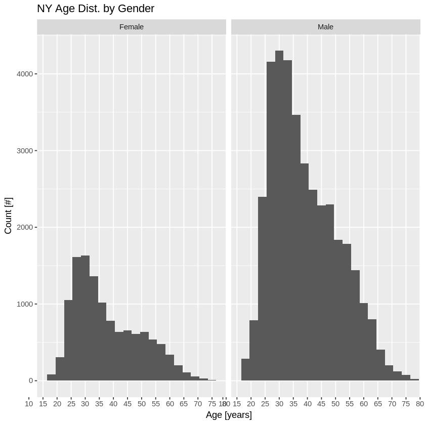

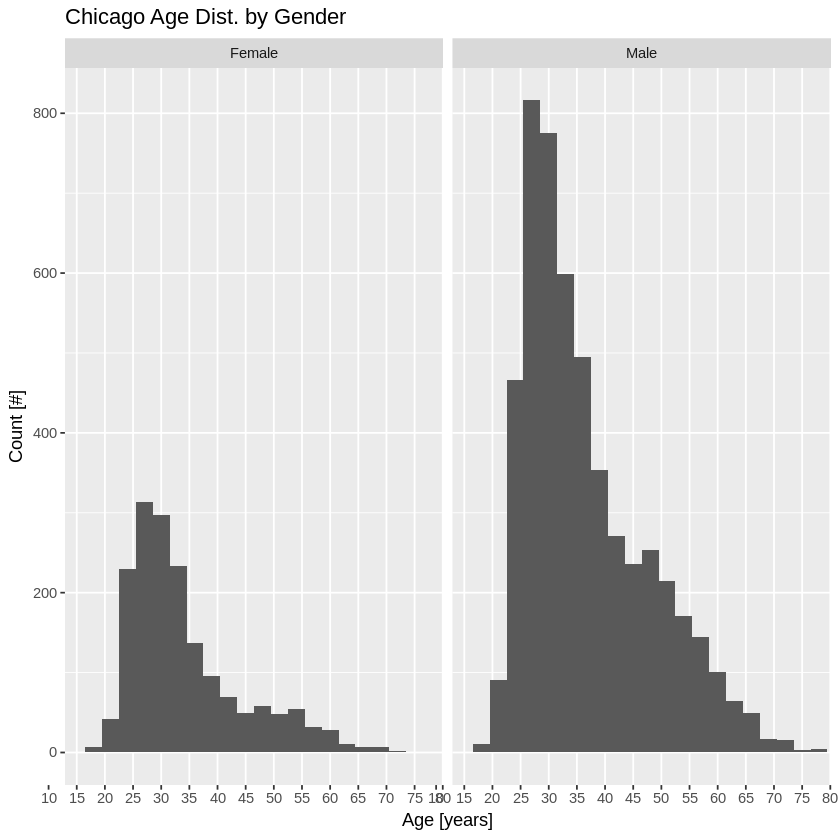

```r
# Here I will transition into visualization
# Using "realistic ages" 10-80
max_age = 80
min_age = 10
ny_age = subset(ny, ny$Age > min_age & ny$Age < max_age & ny$Gender != "")
chi_age = subset(chi, chi$Age > min_age & chi$Age < max_age & chi$Gender != "")

# Plot
qplot(data=ny_age, x= ny_age$Age, binwidth=3, ylab="Count [#]",
    main="NY Age Dist. by Gender") +
    scale_x_discrete(limits=seq(min_age, max_age, 5), name="Age [years]") +
    facet_wrap(~Gender)
qplot(data=chi_age, x= chi_age$Age, binwidth=3, ylab="Count [#]",
    main="Chicago Age Dist. by Gender") +
    scale_x_discrete(limits=seq(min_age, max_age, 5), name="Age [years]") +
    facet_wrap(~Gender)
```

```r
# Q1 SUMMARY
# (Used:
# [data summary, derived columns, filtering NA, univariate histogram plot, faceting])
# In summary, we can see very similar age distributions across both cities and gender
# groups.
# There is a very low user count in the teen and young 20s group.  The counts sharply
# pick up for
# mid and late 20s groups and peaks at around 30 or 35 pretty much consistent with
# the medians discovered
# in the summary stage.  The user count starts to really taper off after 40-45 yo.
# Really no crazy insight
# here as far as gender goes.  We basically see a unimodal right-skewed distribution
# of age among the users.
```

### Question 2

**Here I want to focus on the time of day the trip started. How does it compare among cities?**

```r
# THIS WILL TAKE A WHILE TO RUN
# Your solution code goes here
# Clear added the new column I add every time I run the code
# Not consider missing data
ny = ny[,1:9]
ny = subset(ny, !is.na(ny$Start.Time))
chi = chi[,1:9]
chi = subset(chi, !is.na(chi$Start.Time))
wash = wash[,1:7]
wash = subset(wash, !is.na(wash$Start.Time))

# Set the time label according to the hour the trip strated
# INPUT = date + time of the day in military time
# OUTPUT = 06-12:'MOR', 12-18:'AFT', 18-00:'EVE', 00-06:'NIGHT'
get_time_label <- function(time) {
    hour.of.day = as.numeric(substr(strsplit(toString(time), ":"), 15, 16))
    time.label = "NA"
    if (!is.na(hour.of.day)) {
        if (hour.of.day >= 6 & hour.of.day < 12) {
            time.label = "MOR"
        } else if (hour.of.day >= 12 & hour.of.day < 18) {
            time.label = "AFT"
        } else if (hour.of.day >= 18 & hour.of.day < 24) {
            time.label = "EVE"
        } else {
           time.label = "NIGHT"
        }
    }
    return(time.label)
}

# Add a time of day label TOD (Time Of Day)
ny = cbind(ny, TOD=NA)
chi = cbind(chi, TOD=NA)
wash = cbind(wash, TOD=NA)
samples = max(c(nrow(ny), nrow(chi), nrow(wash)))
print(samples)
for (i in seq(from=1, to=samples, by=1)) { # Loop over times
    # Convert timestamp to hour of the day
    time = ny$Start.Time[i]
    time.label = get_time_label(time)
    ny[i, 10] = time.label # Update the TOD column
    time = chi$Start.Time[i]
    time.label = get_time_label(time)
    chi[i, 10] = time.label # Update the TOD column
    time = wash$Start.Time[i]
    time.label = get_time_label(time)
    wash[i, 8] = time.label # Update the TOD column
    if(counter %% (samples %/% 100) == 0) {
        print(samples %/% counter)
    }
}

# Validate labels
print("NY")
head(ny[,c(2, 10)], 10)
print("CHI")
head(chi[,c(2, 10)], 10)
print("WASH")
head(wash[,c(2, 8)], 10)
```

```
[1] 89051
[1] "NY"
```

| Start.Time | TOD |
| --- | --- |
| 2017-06-11 14:55:05 | AFT |
| 2017-05-11 15:30:11 | AFT |
| 2017-03-29 13:26:26 | AFT |
| 2017-05-08 19:47:18 | EVE |
| 2017-06-21 07:49:16 | MOR |
| 2017-02-22 18:55:24 | EVE |
| 2017-03-06 16:22:53 | AFT |
| 2017-03-07 07:42:24 | MOR |
| 2017-04-02 08:02:36 | MOR |
| 2017-03-01 23:01:31 | EVE |

```
[1] "CHI"
```

| Start.Time | TOD |
| --- | --- |
| 2017-06-23 15:09:32 | AFT |
| 2017-05-25 18:19:03 | EVE |
| 2017-01-04 08:27:49 | MOR |
| 2017-03-06 13:49:38 | AFT |
| 2017-01-17 14:53:07 | AFT |
| 2017-06-26 09:01:20 | MOR |
| 2017-05-26 09:41:44 | MOR |
| 2017-01-21 14:28:38 | AFT |
| 2017-04-20 16:08:51 | AFT |
| 2017-02-06 18:00:47 | EVE |

```
[1] "WASH"
```

| Start.Time | TOD |
| --- | --- |
| 2017-06-21 08:36:34 | MOR |
| 2017-03-11 10:40:00 | MOR |
| 2017-05-30 01:02:59 | NIGHT |
| 2017-04-02 07:48:35 | MOR |
| 2017-06-10 08:36:28 | MOR |
| 2017-05-14 07:18:18 | MOR |
| 2017-06-19 08:41:43 | MOR |
| 2017-06-20 05:54:42 | NIGHT |
| 2017-03-24 20:37:00 | EVE |
| 2017-02-20 21:12:00 | EVE |

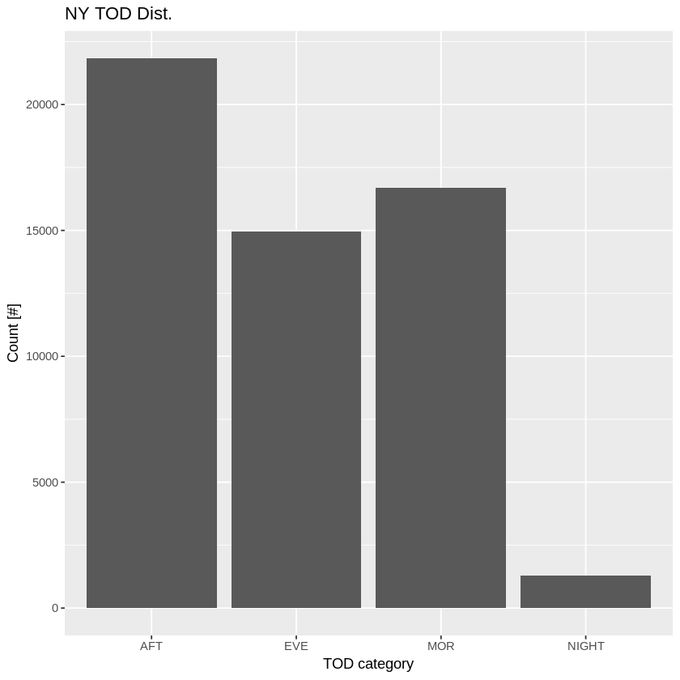

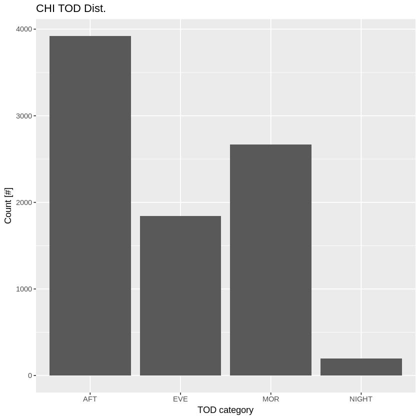

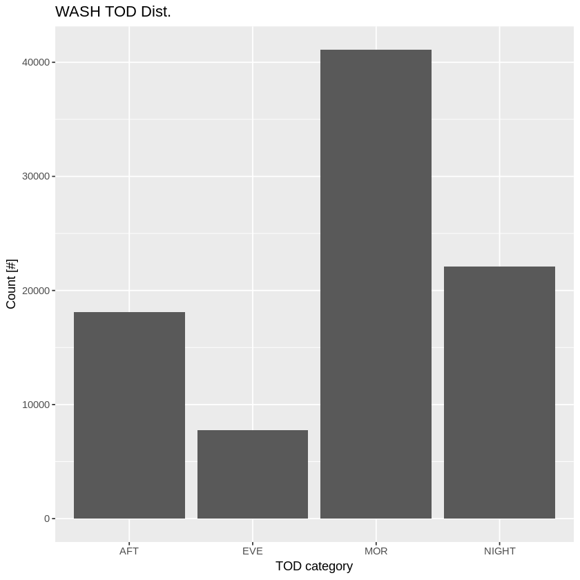

```r
# Plot!
ny = subset(ny, ny$TOD != "NA")
qplot(data=ny, x= ny$TOD, geom="bar", ylab="Count [#]", xlab="TOD category",
      main="NY TOD Dist.")
chi = subset(chi, chi$TOD != "NA")
qplot(data=chi, x= chi$TOD, geom="bar", ylab="Count [#]", xlab="TOD category",
      main="CHI TOD Dist.")
wash = subset(wash, wash$TOD != "NA")
qplot(data=wash, x= wash$TOD, geom="bar", ylab="Count [#]", xlab="TOD category",
      main="WASH TOD Dist.")
```

```r
# Q2 SUMMARY
# (Used:
# [conditional statements, loops, custom function refactoring, barplots])
# Interesting!  People in NY and Chicago are far less likely to take a
#night ride than people
# in DC.  Is that because of crime rates and the safety issue?  Is there a
#problem with our
# bikeshare service?  Who knows.  In both NY and Chicago afternoon rides are
# preferred whereas
# morning rides are preferred in DC.  Those distributions were worth
#investigating (unlike in my
# attempt in question 1) because that could help the company customize
# maintenance times for each
# city.  Sharing this data with government can help the city better
#understands transportation
# trends in their population.
```

### Question 3

**I want to learn more about the trip duration people normally take and if it has anything to do with their age.**

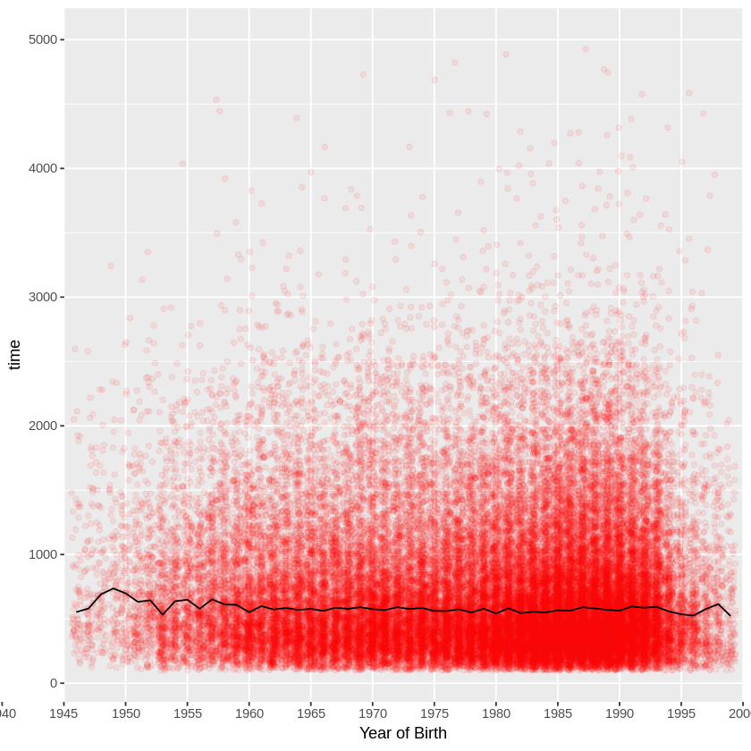

```r
# Your solution code goes here
ny = read.csv('new_york_city.csv')
ny = subset(ny, ny$Birth.Year > 1945 & ny$Birth.Year < 2000)
ggplot(aes(x=ny$Birth.Year, y=ny$Trip.Duration), data=ny,
  main="Trip Duration vs. Age") + ylab("time") +
  ylim(100, 5000) +
  geom_point(alpha=.075, color='Red', position = position_jitter(h=0)) +
  geom_line(stat = 'summary', fun.y=median) +
  scale_x_discrete(limits=seq(1930, 2020, 5), name="Year of Birth")
```

```r
# Q2 SUMMARY (Used: [ggplot syntax, bi-variate analysis])
# Trip duration seems to not vary too much among age groups.  The thickness of
# the plot
# is consistent with previous findings where age was concentrated around 30 yo.
```

## Finishing Up

> Congratulations! You have reached the end of the Explore Bikeshare Data Project. You should be very proud of all you have accomplished!

> **Tip**: Once you are satisfied with your work here, check over your report to make sure that it is satisfies all the areas of the [rubric](https://review.udacity.com/#!/rubrics/2508/view).

## Directions to Submit

> Before you submit your project, you need to create a .html or .pdf version of this notebook in the workspace here. To do that, run the code cell below. If it worked correctly, you should get a return code of 0, and you should see the generated .html file in the workspace directory (click on the orange Jupyter icon in the upper left).

> Alternatively, you can download this report as .html via the **File** > **Download as** submenu, and then manually upload it into the workspace directory by clicking on the orange Jupyter icon in the upper left, then using the Upload button.

> Once you've done this, you can submit your project by clicking on the "Submit Project" button in the lower right here. This will create and submit a zip file with this .ipynb doc and the .html or .pdf version you created. Congratulations!

```r
system('python -m nbconvert Explore_bikeshare_data.ipynb')
```